# Assignment 3: Incarceration

## Introduction

$\qquad$ One of the sharpest manifestations of racism in the United States is its prison system. A complex set of social and political structures, including the over-policing of individuals of color and the war on drugs have led to the disproportionate incarceration of people of color.

$\qquad$ In order to combat such inequalities, I will be analyzing various data sets to expose patterns of inconsistencies within the United States prison system.

$\qquad$ The variables I will be using to measure the prison admission numbers between black/white populations are **black_prison_adm**, **white_prison_adm**, and **total_prison_adm**. These variables will give me a sense of the inequalities among races when it comes to the United States prison system.

## Trends Over Time

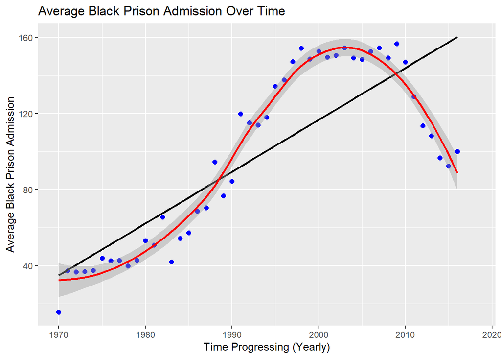

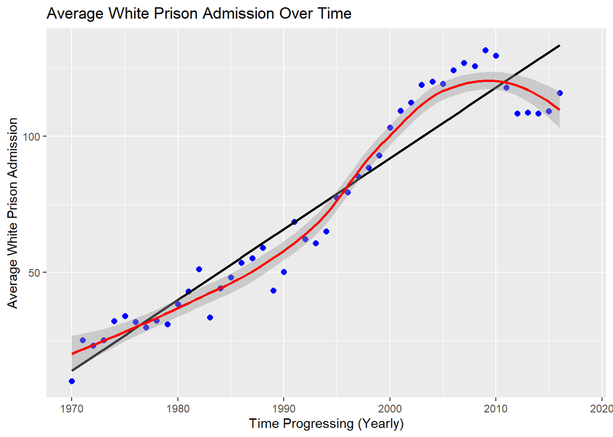

$\qquad$ The graph showing the black prison admission shows extremely high average prison admission numbers going into the early 2000’s and continuing throughout the decade, with the curve going back down after 2010.

$\qquad$ The graph showing the white prison admission shows a much lower maximum then that of the black prison admissions, but a more linear increase throughout the years, with only a very slight dip after 2010.

$\qquad$ What these graphs show is that there *is* an inequality in prison admissions when comparing black and white numbers, or at least there *was*. Throughout the 2000’s the black prison admission numbers skyrocketed much higher than any white prison admission number has ever been, and it continued for about a decade, which is the point where inequality is shown.

## Variable Comparison

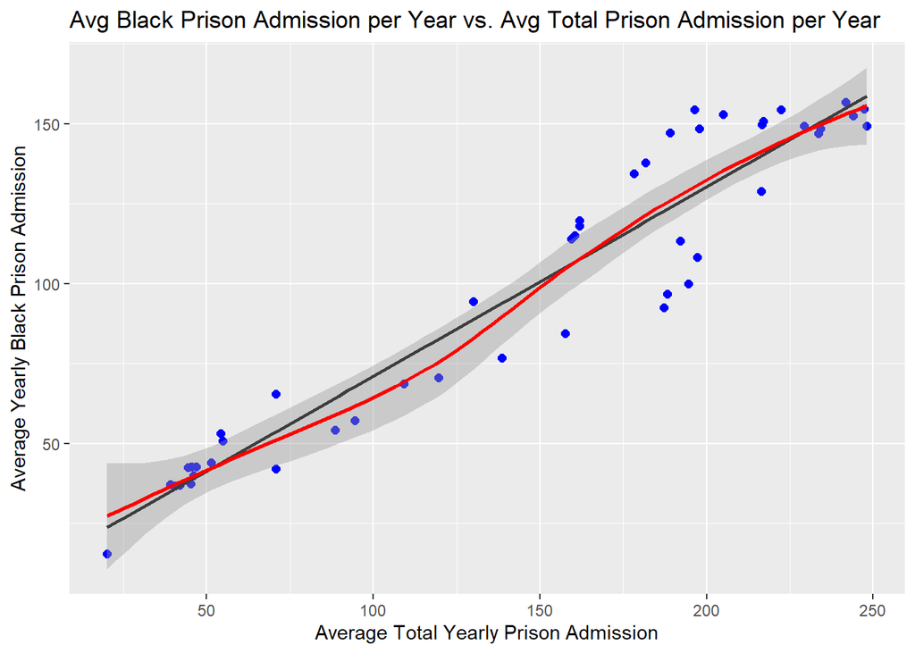

$\qquad$ This variable comparison chart was intended to show how the average black prison admissions change when the total prison admissions (all races) change. This graph shows a much more linear pattern than expected which doesn’t show much about the inequalities in the US prison system, however, there are still more data points above the best fit line. This means that when the total prison admission numbers increase, the black population is likely to be affected the most.

## Map comparisons

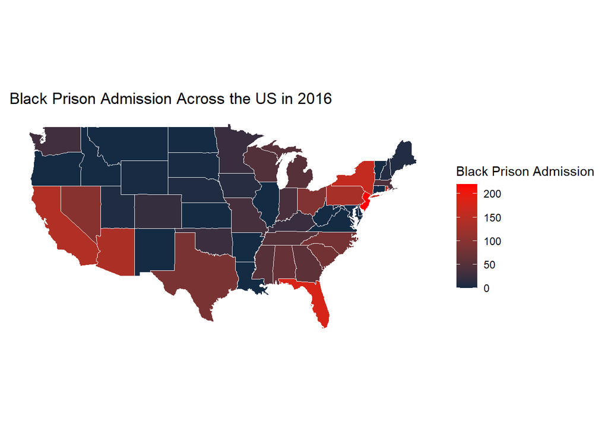

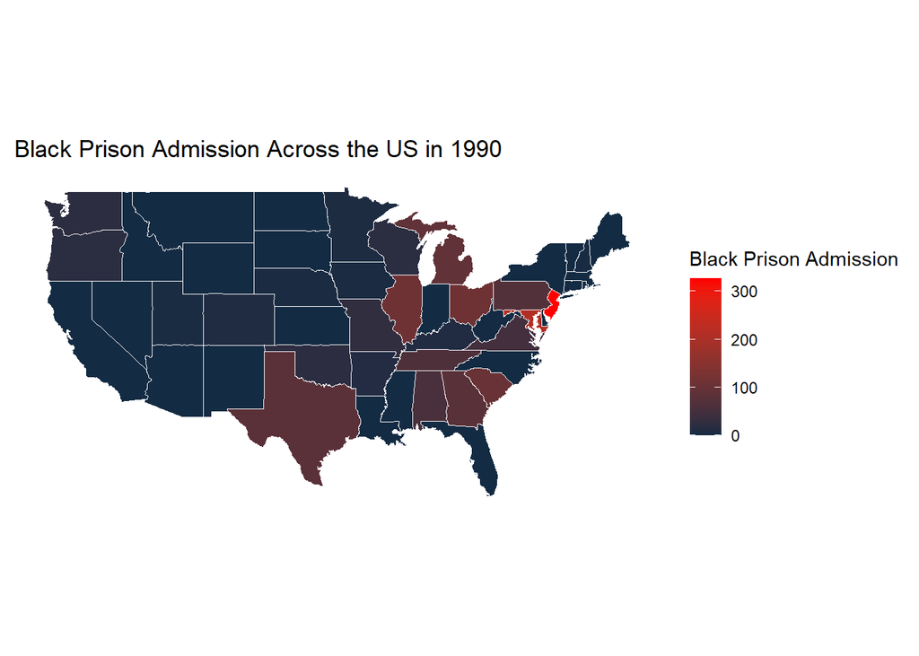

$\qquad$ These maps were created to paint a better visual picture how average black prison admission numbers have changed in the United States from 1990 - 2016. What these maps show is just how many more states have increased their average black prison admission numbers, including but not limited to: California,Arizona, and Nevada with some of the most notable changes. In an equal prison system, changes throughout time are going to happen, but not this drastically, which is another point that raises concern for how the US prison system is ran.

Jeremy J. Dondoyano - 11/2021